# Yelp Exploratory Data Analysis

Dave Braun

February 21, 2019

This notebook will cover some initial findings from the exploratory data analysis of the Yelp brewery data.

```r
yelp <- read.csv('../data/cleanYelp.csv')
head(yelp)
```

## Distribution of dependent variable

These histograms compare the distribution of ratings directly from Yelp against the ones I calculated myself (via a weighted average).

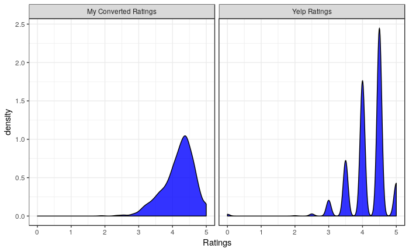

```r
yelp %>%
  gather(rating_type, rating, ratings, my_ratings) %>%
  mutate(rating_type = fct_recode(rating_type, 'Yelp Ratings' = 'ratings', 'My Converted Ratings' = 'my_ratings')) %>%
  ggplot(aes(x = rating)) + geom_density(fill = 'blue', alpha = .8) + xlab('Ratings') + facet_wrap(~rating_type) +
  theme_bw()
```

We can see that Yelp rounds its ratings to the nearest 0.5, and calculating ratings by hand preserves the variability.

## Is take out for a brewery a good thing?

More take out seems better than less take out, right? Perhaps not, says the data:

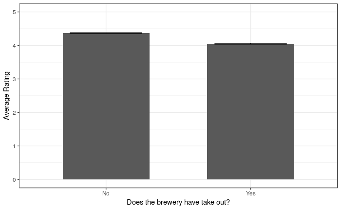

```r
yelp %>%
  group_by(take_out) %>%
  summarize(ratings = mean(my_ratings), se = sd(my_ratings) / sqrt(n())) %>%
  ggplot(aes(x = take_out, y = ratings)) + geom_bar(stat='identity', width = .6) + geom_errorbar(aes(ymin = ratings - se, ymax = ratings + se), width = .5) + ylim(0,5) + theme_bw() +
  xlab('Does the brewery have take out?') + ylab('Average Rating')
```

Overall, breweries without take out are rated more highly than those that do. This seems puzzling, and it might become more clear when investigating how it interacts with other variables.

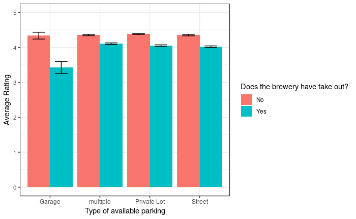

```r
yelp %>%
  filter(parking != 'Valet', parking != 'Validated') %>%
  group_by(parking, take_out) %>%
  summarize(ratings = mean(my_ratings), se = sd(my_ratings, na.rm = TRUE) / sqrt(n())) %>%
 ggplot(aes(x = parking, y = ratings, group = factor(take_out))) + geom_bar(stat = 'identity', aes(fill = factor(take_out)), position = position_dodge(width = .9)) +
 geom_errorbar(aes(ymin = ratings - se, ymax = ratings + se), position = position_dodge(width = .9), width = .5) + ylim(0,5)+ theme_bw() +
  xlab('Type of available parking') + ylab('Average Rating') +
  theme(legend.position = 'top', axis.title.x = element_text(margin = margin(t = 10))) +
 guides(fill = guide_legend(title='Does the brewery have take out?')) + theme_bw() #scale_fill_manual(values = c('black', 'light grey'))
```

## Do people prefer cheaper breweries to more moderate ones?

Sure, all things equal, it’s better to spend less money than more. But people often use price to infer quality: if something is expensive, it must be good. Do higher prices lead to higher ratings?

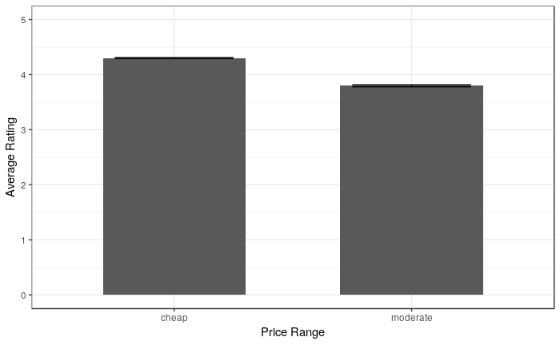

```r
yelp %>%
  filter(price_range != 'expensive') %>%
  group_by(price_range) %>%
  summarize(ratings = mean(my_ratings), se = sd(my_ratings) / sqrt(n())) %>%
  ggplot(aes(x = price_range, y = ratings)) + geom_bar(stat='identity', width = .6) + geom_errorbar(aes(ymin = ratings - se, ymax = ratings + se), width = .5) + ylim(0,5) + theme_bw() +
  ylab('Average Rating') + xlab('Price Range')
```

It looks like cheaper prices drive up ratings. Maybe people aren’t fooled by the illusion of price indicating quality, maybe they just know good beer and prefer it to be cheap. It’s also possible that, all things equal, people just like things that are cheap!

Can anything else explain how price range affects average rating? Maybe people only have a strong preference about the price range of a brewery when it *doesn’t* accept credit cards. It can be an extra hassle when scraping together the spare change in your car just isn’t enough to buy a refreshing drink.

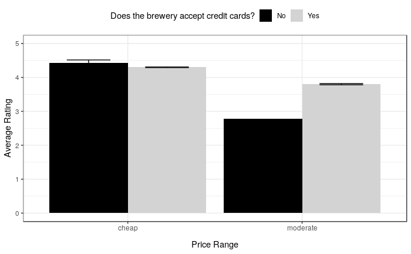

```r
yelp %>%
  filter(price_range != 'expensive') %>%
  group_by(price_range, accepts_credit_cards) %>%
  summarize(ratings = mean(my_ratings), se = sd(my_ratings, na.rm = TRUE) / sqrt(n())) %>%
 ggplot(aes(x = price_range, y = ratings, group = factor(accepts_credit_cards))) + geom_bar(stat = 'identity', aes(fill = factor(accepts_credit_cards)), position = position_dodge(width = .9)) +
 geom_errorbar(aes(ymin = ratings - se, ymax = ratings + se), position = position_dodge(width = .9), width = .5) + ylim(0,5) + theme_bw() +
  xlab('Price Range') + ylab('Average Rating') +
  theme(legend.position = 'top', axis.title.x = element_text(margin = margin(t = 10))) +
 guides(fill = guide_legend(title='Does the brewery accept credit cards?')) + scale_fill_manual(values = c('black', 'light grey'))
```